# RansomwareAttacksAnalysis

Zack Espinoza, Christian Garza

2024-04-16

# Load data

```r
library(tidyverse)
```

```r
library(dplyr)
library(ggplot2)
library(dslabs)
library(ggh4x)#Installed
#<<<<<<< HEAD
#=======
#install.packages("patchwork") #run if patchwork not downloaded
library(patchwork)
#=======
library(geosphere) #installed
library(maps) #Installed
#>>>>>>> eb922c317e58f6a713f58f0c22e0296e7311011c
RA <- read.csv("Ransomware Attacks - Ransomware Attacks.csv") #Ransomware Attacks
bitcoinHigh <- read.csv("bitcoinHighPrice.csv") #for bitcoin cost graph
```

# Introduction

Ransomware refers to a type of malware that locks a user out of their system and can hold their data hostage. The expectation is that the victim will pay a ransom for the attacker to release the data back to the user or withhold it from the public. With the rise of cryptocurrency, these attacks have become far more common than the past due to the unregulated nature of coins so criminals can receive a ransom and hide their tracks. Our goal is to analyze some of these attacks and find out some answers about both the attacks, as well as common victims and outcomes of these attacks.

# Explaining the Data

Due to the nature of these attacks, many of the examples are going to have unknown data such as ransom amount, this is because companies do not like making it public that their security has been breached unless necessary or the attacker has made their intentions public, or worst case scenario, leaked the data to the public or sold it on the black market. This could mean that our data does not apply to the whole situation of ransomware attacks, but we can make conclusions about the data we do know.

# Questions: Christian(1, 2, 4, 5) Zack(3, 6, 7)

1. What industries are attacked by Ransomware the most?
2. Where are these attacks coming from
3. Does a company’s revenue or size have any correlation with the ransom amount?
4. Which regions are being attacked the most.
5. Which hacker groups are attacking which region most frequently, Europe, America, Asia/Oceania.
6. Average ransom amount vs average amount actually paid.
7. Is ransomware that we know about trending down or gaining popularity? Is this changed by the current price of bitcoin?

# Unfiltered Data

```r
glimpse(RA)
```

```
## Rows: 359
## Columns: 29
## $ Target                               <chr> "Kaseya", "Salvation Army", "Grup…
## $ AKA                                  <chr> "", "", "", "", "", "Mountain Reg…
## $ description                          <chr> "", "", "Brazil's largest diagnos…
## $ sector                               <chr> "tech", "", "healthcare", "govern…
## $ organisation.size.1.5.10.25.100.300. <int> 300, 1, 10, 1, 1, 1, 5, 1, 1, 1, …
## $ revenue..USD.million                 <int> 300, NA, 686, NA, 9, NA, 22, NA, …
## $ cost                                 <chr> "70", "unknown", "unknown", "unkn…
## $ ransom.cost                          <dbl> 70.00, NA, NA, NA, NA, NA, NA, NA…
## $ data.note                            <chr> "", "", "", "", "", "", "", "", "…
## $ ransom.paid                          <chr> "unknown", "unknown", "unknown", …
## $ YEAR.code                            <int> 1, 1, 1, 1, 1, 1, 1, 1, 1, 1, 1, …
## $ YEAR                                 <int> 2021, 2021, 2021, 2021, 2021, 202…
## $ month                                <chr> "JUL", "JUN", "JUN", "JUN", "JUN"…
```

[output cut: 16 more lines]

# Explaining the Columns

- **Target/AKA/description** - Name of the organization attacked
- **Sector** - What kind of company they are, healthcare, tech, etc
- **Size** - Number of employees
- **revenue** - revenue of the company in millions USD
- **cost/ransom** - cost of the ransom and explaination in millions
- **Ransomware** - the individual or group taking credit for the attack

### Nullifying irrelevant info from dataset

```r
RA$AKA <- NULL
RA$description <- NULL
RA$organisation.size.1.5.10.25.100.300. <- NULL
RA$data.note <- NULL
RA$YEAR.code <- NULL
RA$interesting.story..edited. <- NULL
RA$interesting.story. <- NULL
RA$stock.symbol <- NULL
RA$interesting.story..long. <- NULL
RA$revenue.as.of <- NULL
RA$no.of.employees <- NULL
RA$Data.Note <- NULL
RA$Source.Name <- NULL
RA$URL <- NULL
RA$URL.2 <- NULL
RA$URL.3 <- NULL
RA$URL.4 <- NULL
RA$URL.5 <- NULL
RA$X.ID <- NULL
```

# 1. What Industries Are Attacked By Ransomware The Most?

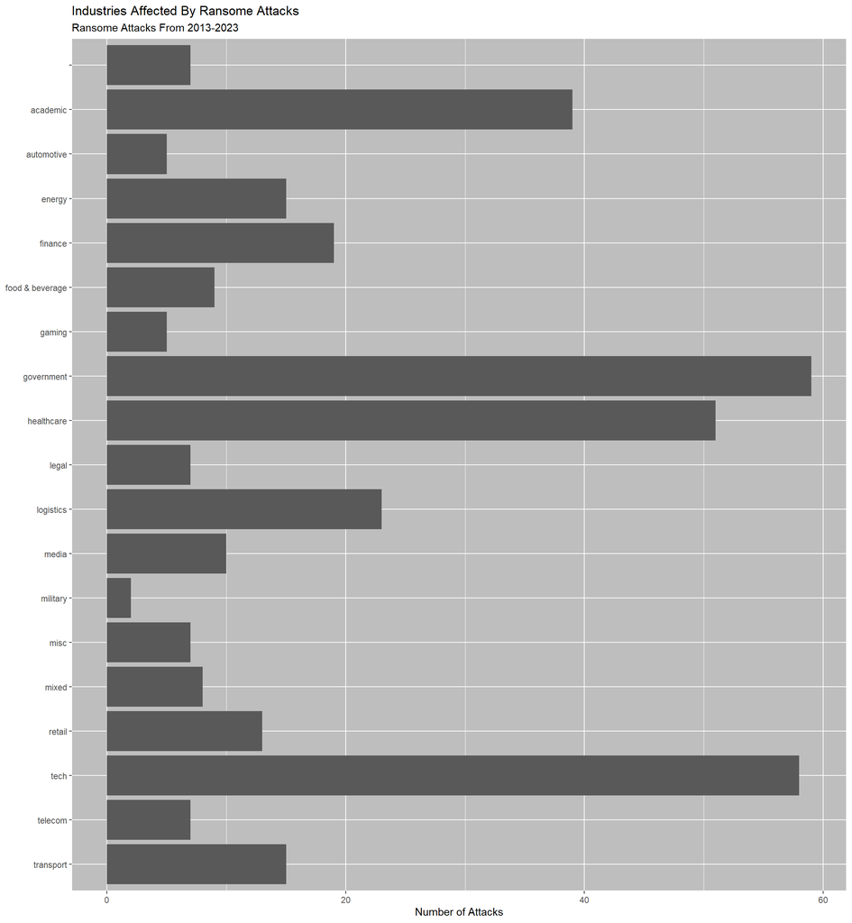

```r
most_affected <- RA %>% group_by(sector) %>% summarise(n=n()) %>% arrange(desc(n), sector)

ggplot(most_affected, aes(y=fct_rev(sector), x = n)) + geom_col() + scale_x_continuous() + theme(panel.background = element_rect(color = "white", fill = "gray")) + labs(y=NULL, x = "Number of Attacks") + labs(title = "Industries Affected By Ransome Attacks", subtitle = "Ransome Attacks From 2013-2023")
```

# Top 5 Industries Attacked By Ransomware The Most

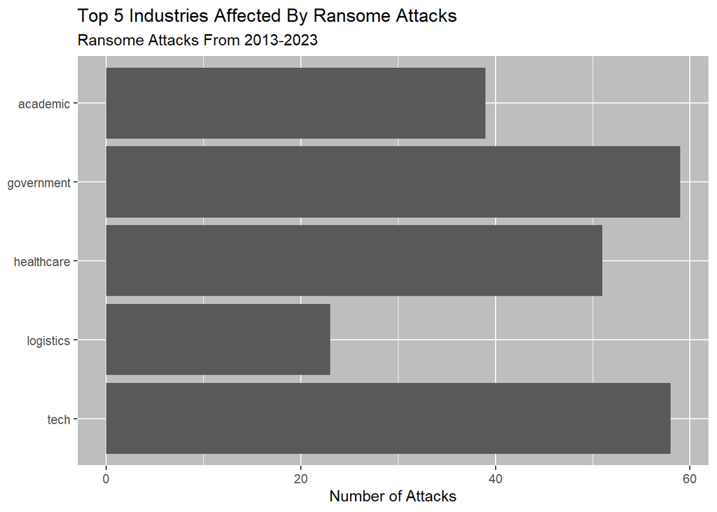

```r
Top_5_RA <- RA %>% group_by(sector) %>% summarise(n=n()) %>% arrange(desc(n)) %>% head(5)

most_affected <- RA %>% group_by(sector) %>% summarise(n=n()) %>% arrange(desc(n), sector) %>% slice(1:5)

ggplot(most_affected, aes(y=fct_rev(sector), x = n)) + geom_col() + scale_x_continuous() + theme(panel.background = element_rect(color = "white", fill = "gray")) + labs(y=NULL, x = "Number of Attacks") + labs(title = "Top 5 Industries Affected By Ransome Attacks", subtitle = "Ransome Attacks From 2013-2023")
```

# 2. Where are these attacks coming from

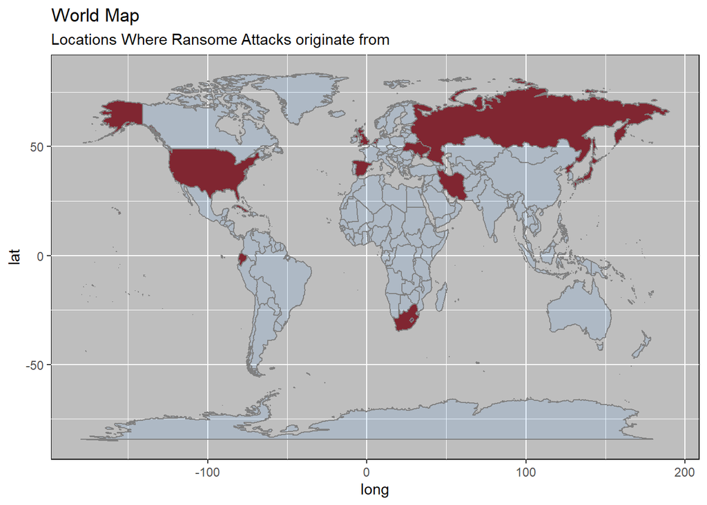

```r
RA_Hackers <- RA %>% group_by(Ransomware) %>% summarise(n=n())

Temp_RA_ATT <- RA_Hackers$region <- c("N/A", "USA", "Japan",    "Russia",   "Russia",   "Russia",   "Russia",   "Russia",   "Iran", "Russia",   "Russia",   "Russia",   "Russia",   "Russia",   "Cuba", "Russia",   "Russia",   "UK",   "Ukraine",  "USA",  "Turky",    "Russia",   "Russia",   "Ukraine",  "Ecuador",  "Russia",   "Russia",   "Russia",   "Russia",   "Russia",   "Russia",   "Russia",   "Russia",   "N/A",  "Russia",   "Russia",   "Netherlands",  "Iran", "Russia",   "Russia",   "Russia",   "Russia",   "Spain",    "Russia",   "Russia",   "Russia",   "Russia",   "Russia",   "Russia",   "USA",  "Iran", "South Africa", "Russia",   "Russia",   "Russia",   "Russia",   "North Korea",  "Russia",   "Chinese",  "Russia",   "N/A")

RA_loc_of_att <- merge(RA, RA_Hackers, by = c("Ransomware"), all.x = TRUE)

RA_loc_of_att$n <- NULL
RA_V.2 <- RA_loc_of_att[, c(2, 3, 8, 9, 10, 1, 11, 6, 7, 4, 5)]
RA_Attacker_Map <- RA_V.2 %>% group_by(region) %>% summarise()


mapdata. <- map_data("world")

mapdata <- left_join(mapdata., RA_Hackers, by="region")
mapdata1 <- mapdata %>% filter(!is.na(mapdata$Ransomware))
map1 <- ggplot(mapdata1, aes(x= long, y = lat, group=group)) +
  geom_polygon(aes(fill = region),fill = "firebrick4", color = "black") +
  borders(alpha = 0.1, fill = "dodgerblue") +
  theme(panel.background = element_rect(color = "black", fill = "gray")) +
  labs(title = "World Map ", subtitle = "Locations Where Ransome Attacks originate from")

map1
```

```r
RA_Attacker_Map #List of Ransome Countries (WIP) Need to make Key
```

```
## # A tibble: 15 × 1
##    region
##    <chr>
##  1 Chinese
##  2 Cuba
##  3 Ecuador
##  4 Iran
##  5 Japan
##  6 N/A
##  7 Netherlands
##  8 North Korea
##  9 Russia
## 10 South Africa
## 11 Spain
## 12 Turky
## 13 UK
## 14 USA
## 15 Ukraine
```

# 3. Does a company’s revenue or size have any correlation with the ransom amount?

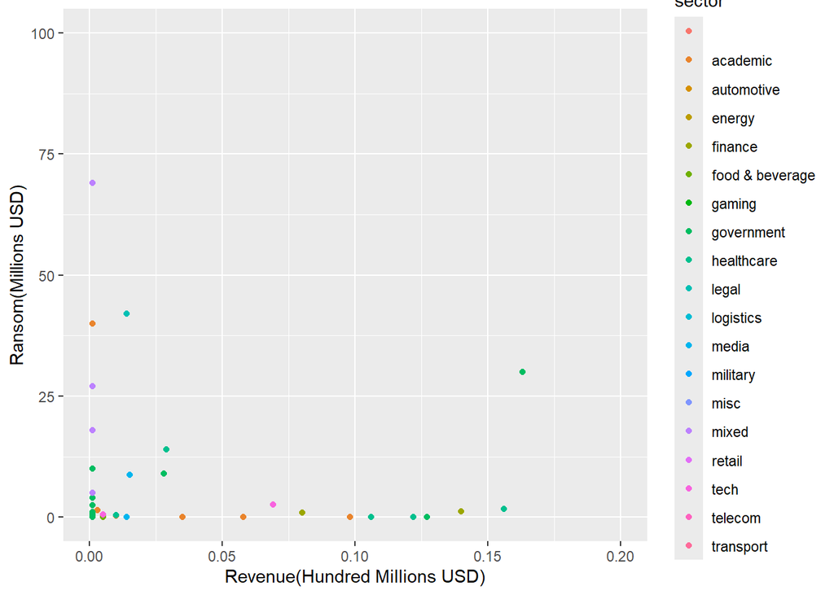

```r
scatterPlot <- RA %>% ggplot(aes(x = revenue..USD.million, y = ransom.cost, color = sector, na.rm = T)) +
  geom_point() +
   labs(
    x = "Revenue(Hundred Millions USD)" ,
    y = "Ransom(Millions USD)"
  ) +
  scale_x_continuous(labels = scales::number_format(scale = 1e-3), limits = c(0,200)) +
  scale_y_continuous(limits = c(0, 100))


scatterPlot
```

There does not seem to be any relation between the revenue of a company and the requested ransom amount, nor does it have any correlation with what sector the company is in.